# 2020 Presidential Election Finances

Sarah Edelson

## Introduction

[figure not shown]

We live in a world where money and politics are largely intertwined. This fact is starkly apparent when examining the net worth of certain 2020 presidential candidates. Michael Bloomberg, who has a net worth of $59 billion, spent over $1 billion on his own candidacy. Tom Steyer, a former hedge fund manager and billionaire, also made a run for President. The 45th President, Donald Trump, made a fortune through his real estate empire, allocating millions to his campaign. The 2020 election, including both presidential and congressional races, cost a record-breaking *$14 billion*. Aside from candidates’ own wealth, **where is the rest of this campaign money coming from?** I set out to address questions pertaining to 2020 election finances, seeking to understand who is making political donations and to whom they are supporting. The three main datasets I used were all from the [Federal Election Commission](https://www.fec.gov/data/elections/president/2020/), and focused on independent expenditures, individual contributions by state, and individual contributions broken down by expenditure level. The last dataset, which has observations for each contribution made by a person living in Amherst from 2019-2020 (85,662 observations), was a filtered version of [this](https://www.fec.gov/data/receipts/individual-contributions/?recipient_committee_type=P&contributor_zip=01002&contributor_city=Amherst&two_year_transaction_period=2020) entire individual contributions dataset, and also removed variables such as name, address, zip code, and occupation.

## Independent Expenditures for Joe Biden & Donald Trump

I used the independent expenditures dataset to understand how much money different organizations spent either supporting or opposing Joe Biden and Donald Trump, the two main presidential candidates in the 2020 general election. The dataset contained 863 observations, indicating that there were expenditures from 863 organizations, ranging in size from $2.80 to over $133 million. In order to make a network visualizing the connections between different organizations and the two candidates, I filtered the data to include only donations that were larger than $10 million.

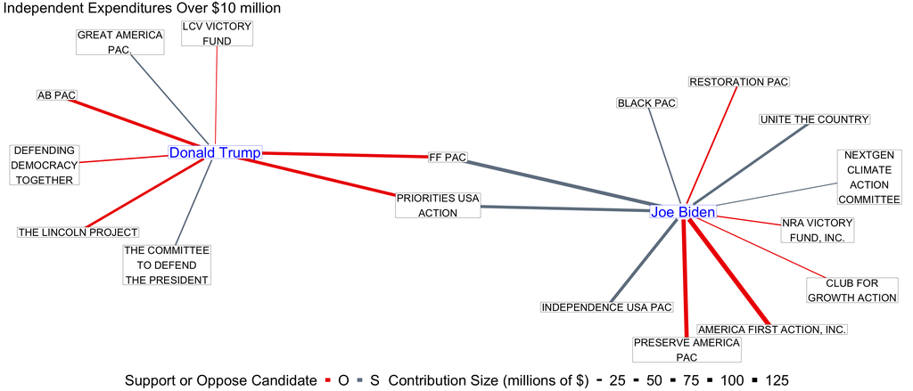

The network indicates that:

- The largest donors were skewed more towards Biden then Trump. Biden received support from six organizations, while Trump received support from two. Five organizations opposed Biden while six opposed Trump.
- Two organizations spent money supporting one candidate and opposing the other: the **FF Pac** and **Priorities USA Action** made expenditures supporting Joe Biden and opposing Donald Trump.
- Candidate priorities align with donors. Conservatives have historically been large advocates for gun rights, explaining why the **NRA Victory Fund** would oppose Biden. Democrats are more invested in combating problems pertaining to climate change and environmental justice, leading the **NextGen Climate Action Committee** to support Biden.

Moving forward, it would be interesting to examine how the number of PACs/organizations and their missions differ at different levels of expenditures.

## All Independent Expenditures

While the network only draws attention to the largest expenditures for the two major candidates, explore this interactive table to learn more about expenditures of all sizes and to all candidates.

|  | candidate_name | committee_name | total | support_oppose_indicator |
| --- | --- | --- | --- | --- |
| 1 | BIDEN, JOSEPH R JR | AMERICA FIRST ACTION, INC. | 133775069.12 | O |
| 2 | BIDEN, JOSEPH R JR | PRESERVE AMERICA PAC | 102983483.91 | O |
| 3 | BIDEN, JOSEPH R JR | FF PAC | 74018835.92 | S |
| 4 | TRUMP, DONALD J. | PRIORITIES USA ACTION | 54922266.57 | O |
| 5 | TRUMP, DONALD J. | FF PAC | 54420035.57 | O |
| 6 | BIDEN, JOSEPH R JR | INDEPENDENCE USA PAC | 54288408.16 | S |
| 7 | TRUMP, DONALD J. | AB PAC | 51150312.79 | O |
| 8 | BIDEN, JOSEPH R JR | PRIORITIES USA ACTION | 50826552.68 | S |
| 9 | BIDEN, JOSEPH R JR | UNITE THE COUNTRY | 37522948.96 | S |
| 10 | TRUMP, DONALD J. | THE LINCOLN PROJECT | 33837162.38 | O |

[output cut: 853 more lines]

## Individual Contributions

Besides PACs and Super PACs, a significant portion of campaign spending comes from individual contributions. Which candidates amassed the most support from the general public, and which states had the largest total individual contributions?

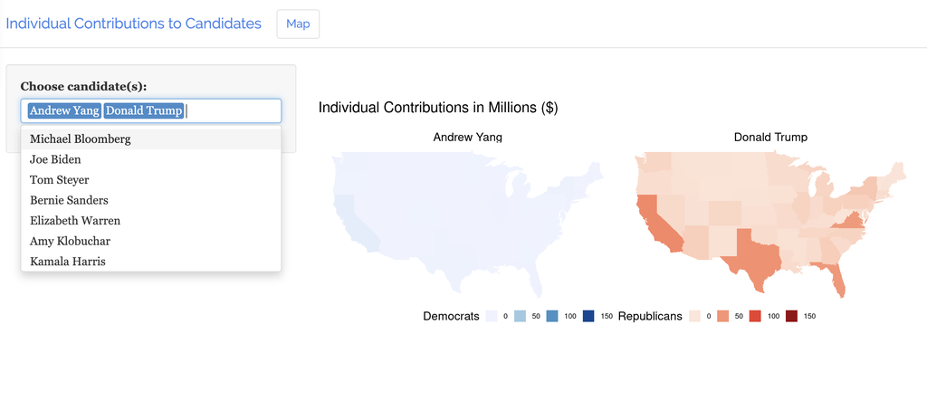

This is a static image of the interactive map, outining total individual contributions by state for different candidates. The map was created using the individual contributions dataset, which I converted to a long format so that each observation included the state, state contribution, and candidate.

Click [here](http://sedelson31.shinyapps.io/IndividualContributionsMap) to view the interactive map.

The map shows that:

- Donald Trump received the most contributions from **California**, **Texas**, **Florida**, and **Virginia**.
- Joe Biden received the most contributions from **California** and **New York**.
- Certain candidates who lost in the primaries tended to receive most of their contributions from the states which they have served. For example, Kamala Harris was a California senator and acquired most of her donations from that state. Amy Klobuchar received the most contributions from Minnesota, where she was a senator. Massachusetts senator Elizabeth Warren also obtained a majority of her contributions from her home state.

This map only conveys totals for each state, but I would be interested in further analyzing the average contribution across states, or even more specific municipal levels, in addition to other demographic factors influencing donations. For example, we could test the belief that lower-income people residing in rural areas tend to support Trump by examining where many of the people that donated up to $20 lived.

[This](https://www.nytimes.com/interactive/2020/09/02/upshot/america-political-spectrum.html) New York Times Upshot article called *“The True Colors of America’s Political Spectrum Are Gray and Green”* examines how satellite images of the United States tend to be accurate indicators of voting patterns. In the 2016 election, places with more greenery (often rural areas) leaned towards Trump, while places with more gray in the satellite images (indicating roads and buildings) leaned towards Clinton. An extension of this project could be examining how the average number and value of expenditures for each candidate varies across the satellite image color spectrum.

## Individual Contributions Breakdown

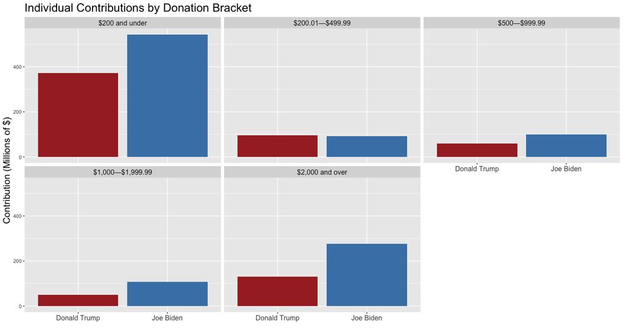

- For both candidates, the most money was made in the $200 and under category.
- Joe Biden received the most money for four of the five spending brackets.
- Donald Trump garnered more money only in the $200.01 to $499.99 range.

The limitation of this bar graph is that it does not tell us the number of donations made for each candidate. It is quite plausible that Trump had more donors than Biden in certain brackets, but these donors gave at the lower bound of the range, resulting in a lower overall total. I would be interested in acquiring data that show the number and exact value of each individual donation within specific spending ranges.

## Donations from UMass Employees (who live in Amherst) to Main Candidates

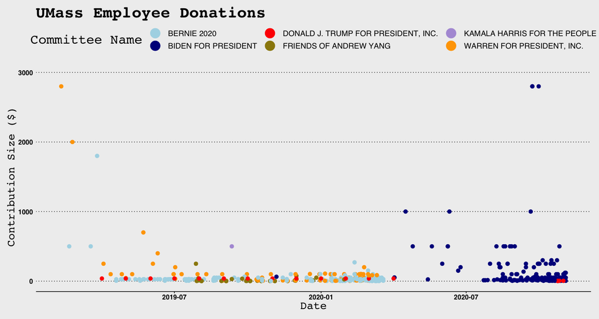

This scatter plot shows all 2019-2020 donations made by individuals who are UMass employees residing in Amherst. It seems that in the early days of the primaries, many UMass employees were optimistic that either Elizabeth Warren or Bernie Sanders would clinch the Democratic nomination, as most of the donations between June 2019 and January 2020 were to these two candidates. There were also quite a few donations to Andrew Yang during this time frame. Once Biden clinched the Democratic nomination at the August 2020 Democratic National Convention, donations for Biden came flooding in. In total, 195 donations were made to Biden, while 17 donations were made to Trump. It is also apparent that there is a “U” shaped pattern of donation size over time. There were large donations to Elizabeth Warren and Bernie Sanders in early 2019, as these candidates showed promise for winning the primaries. Throughout the rest of 2019, donations were much smaller, largely remaining in the under $200 range. As the primaries drew closer, there were many larger donations, and donations continued to increase up until the election.

## Conclusion

This project explores 2020 election finance information at many levels, examining expenditures on both a macro and micro scale. The network and table convey information about expenditures by PACs and Super PACS, the map shows aggregated individual contributions by state, and the scatter plots display individual contributions from UMass employees who live in Amherst. While many people believe that large organizations and Super PACs comprise the majority of campaign spending, in reality, individual contributions are the most important. In the 2020 election, 8.13% of funds were from PACs and organizations and 13.01% were from self-funding, while 63.93% were from individual donations (with the last 14.93% labeled as “other”). Ultimately, it is important to recognize the critical role that the general public has in the electoral process, not only from a voting perspective, but from a spending perspective.

## Citations

- “2020 Election to Cost $14 Billion, Blowing Away Spending Records.” OpenSecrets News, 28 Oct. 2020, www.opensecrets.org/news/2020/10/cost-of-2020-election-14billion-update/.
- “2020 Election United States President.” FEC.gov, www.fec.gov/data/elections/president/2020/.
- “Browse Individual Contributions.” FEC.gov, www.fec.gov/data/receipts/individual-contributions/?recipient_committee_type=P&contributor_zip=01002&contributor_city=Amherst&two_year_transaction_period=2020.
- Schwartz, Brian. “Total 2020 Election Spending to Hit Nearly $14 Billion, More than Double 2016’s Sum.” CNBC, CNBC, 2 Nov. 2020, www.cnbc.com/2020/10/28/2020-election-spending-to-hit-nearly-14-billion-a-record.html.
- Wallace, Tim, and Krishna Karra. “The True Colors of America’s Political Spectrum Are Gray and Green.” The New York Times, The New York Times, 2 Sept. 2020, www.nytimes.com/interactive/2020/09/02/upshot/america-political-spectrum.html.
- “Wall Street Journal Theme - theme_wsj.” Ggthemes, jrnold.github.io/ggthemes/reference/theme_wsj.html.
- Wilke, Claus. “Relayer.” GitHub, github.com/clauswilke/relayer.